# ASC_TIMEcourse_limma_plusDay15_more_contrasts

```r
paste("And", max(0,nrow(go_down)-20), "other terms above pval threshold")
```

```
## [1] "And 143 other terms above pval threshold"
```

Metochondria/metabolism makes sense, hallmark adipogenesis. There’s also reactome translation.

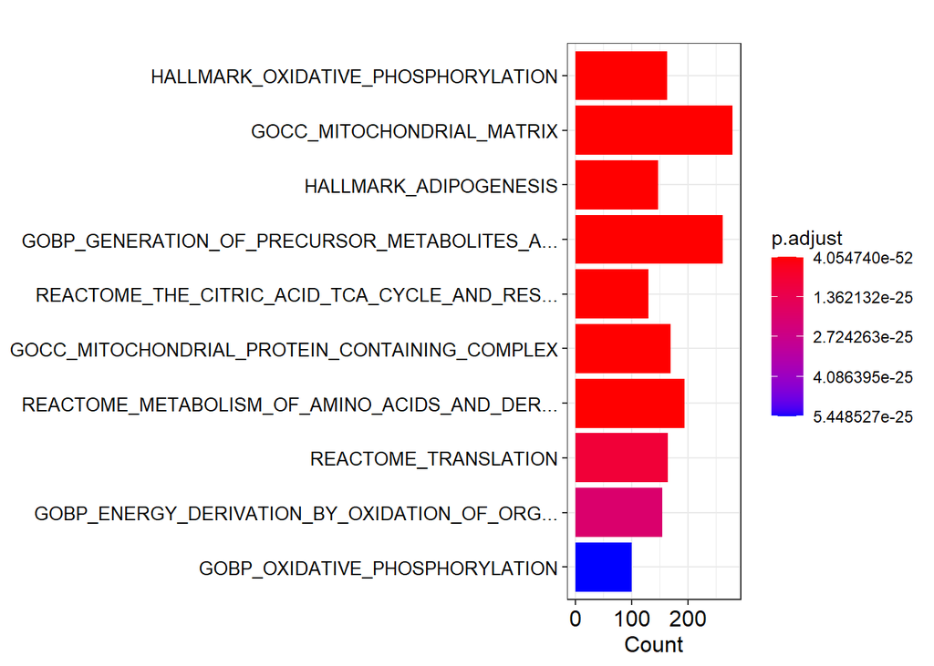

```r
barplot(go_up, showCategory=10) + scale_y_discrete(label=function(x) stringr::str_trunc(x,45)) +
    theme(axis.text.y = element_text(size=10))
```

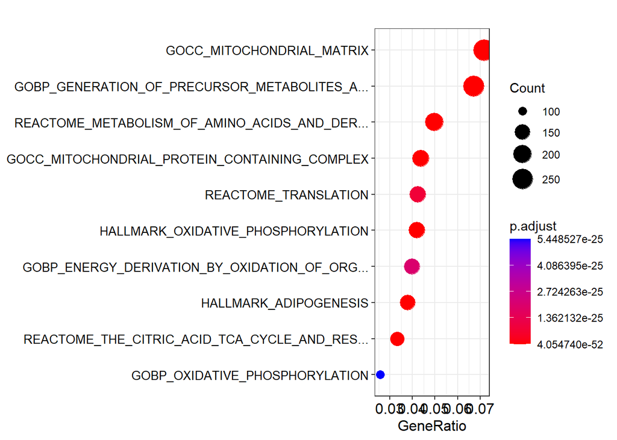

```r
dotplot(go_up, showCategory=10) + scale_y_discrete(label=function(x) stringr::str_trunc(x,45)) +
    theme(axis.text.y = element_text(size=10))
```

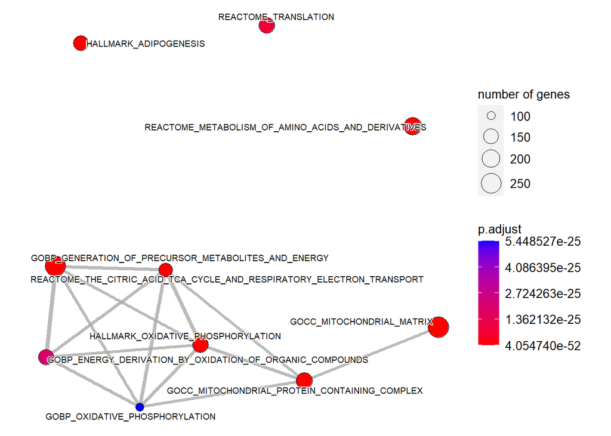

```r
emapplot(pairwise_termsim(go_up), showCategory = 10, cex_label_category = 0.5)
```

```r
length(final$gene_name[final$P.Value.d0_to_d15 < 0.01 &
                                            final$d0_to_d15.D7 < -1 &
                                            final$d0_to_d15.D13 < -1])
```

```
## [1] 3385
```

```r
go_down_hlf = enricher(gene=final$gene_name[final$P.Value.d0_to_d15 < 0.01 &
                                            final$d0_to_d15.D7 < -1 &
                                            final$d0_to_d15.D13 < -1],
              TERM2GENE = some.molsig,
              minGSSize = 10,
              universe = final$gene_name)
head(go_down_hlf, n=20)[c(3:7)]
```

```
##                                               GeneRatio   BgRatio       pvalue
## GOMF_RECEPTOR_REGULATOR_ACTIVITY                57/1213 277/13605 1.405703e-09
## GOCC_PLASMA_MEMBRANE_PROTEIN_COMPLEX            70/1213 393/13605 1.264919e-08
## GOCC_POSTSYNAPTIC_MEMBRANE                      40/1213 173/13605 1.381338e-08
## GOCC_MHC_CLASS_II_PROTEIN_COMPLEX                9/1213  11/13605 1.614144e-08
## GOCC_EXTERNAL_ENCAPSULATING_STRUCTURE           71/1213 410/13605 3.272424e-08
## GOCC_SYNAPTIC_MEMBRANE                          51/1213 258/13605 4.143446e-08
## KEGG_SYSTEMIC_LUPUS_ERYTHEMATOSUS               15/1213  34/13605 5.982416e-08
## GOCC_CILIARY_PLASM                              24/1213  87/13605 3.572263e-07
## KEGG_GRAFT_VERSUS_HOST_DISEASE                  11/1213  21/13605 4.121955e-07
## KEGG_TYPE_I_DIABETES_MELLITUS                   12/1213  26/13605 7.073772e-07
## GOBP_MICROTUBULE_BUNDLE_FORMATION               21/1213  77/13605 2.332300e-06
## GOCC_MHC_PROTEIN_COMPLEX                        10/1213  20/13605 2.457310e-06
## KEGG_ASTHMA                                      8/1213  13/13605 3.341414e-06
## HALLMARK_EPITHELIAL_MESENCHYMAL_TRANSITION      38/1213 196/13605 3.535968e-06
## WP_ALLOGRAFT_REJECTION                          17/1213  56/13605 4.330983e-06
## GOCC_COLLAGEN_CONTAINING_EXTRACELLULAR_MATRIX   54/1213 323/13605 4.366040e-06
## GOCC_CILIUM                                     72/1213 474/13605 4.497379e-06
## GOBP_SYNAPTIC_SIGNALING                         73/1213 483/13605 4.637147e-06
## GOBP_TAXIS                                      71/1213 467/13605 5.075002e-06
## GOBP_PROTEIN_LOCALIZATION_TO_SYNAPSE            18/1213  63/13605 5.944218e-06
##                                                   p.adjust       qvalue
## GOMF_RECEPTOR_REGULATOR_ACTIVITY              9.293101e-06 8.555551e-06
## GOCC_PLASMA_MEMBRANE_PROTEIN_COMPLEX          2.667777e-05 2.456048e-05
## GOCC_POSTSYNAPTIC_MEMBRANE                    2.667777e-05 2.456048e-05
## GOCC_MHC_CLASS_II_PROTEIN_COMPLEX             2.667777e-05 2.456048e-05
## GOCC_EXTERNAL_ENCAPSULATING_STRUCTURE         4.326799e-05 3.983401e-05
## GOCC_SYNAPTIC_MEMBRANE                        4.565387e-05 4.203053e-05
## KEGG_SYSTEMIC_LUPUS_ERYTHEMATOSUS             5.649964e-05 5.201553e-05
## GOCC_CILIARY_PLASM                            2.952029e-04 2.717740e-04
## KEGG_GRAFT_VERSUS_HOST_DISEASE                3.027805e-04 2.787502e-04
## KEGG_TYPE_I_DIABETES_MELLITUS                 4.676471e-04 4.305321e-04
## GOBP_MICROTUBULE_BUNDLE_FORMATION             1.353773e-03 1.246330e-03
## GOCC_MHC_PROTEIN_COMPLEX                      1.353773e-03 1.246330e-03
## KEGG_ASTHMA                                   1.669735e-03 1.537216e-03
## HALLMARK_EPITHELIAL_MESENCHYMAL_TRANSITION    1.669735e-03 1.537216e-03
## WP_ALLOGRAFT_REJECTION                        1.703121e-03 1.567952e-03
## GOCC_COLLAGEN_CONTAINING_EXTRACELLULAR_MATRIX 1.703121e-03 1.567952e-03
## GOCC_CILIUM                                   1.703121e-03 1.567952e-03
## GOBP_SYNAPTIC_SIGNALING                       1.703121e-03 1.567952e-03
## GOBP_TAXIS                                    1.765834e-03 1.625688e-03
## GOBP_PROTEIN_LOCALIZATION_TO_SYNAPSE          1.964861e-03 1.808920e-03
```

```r
paste("And", max(0,nrow(go_down_hlf)-20), "other terms above pval threshold")
```

```
## [1] "And 158 other terms above pval threshold"
```

When you limit for at least 1 logFC (at least 2 fold change) we drop ~2k genes and get some vaguer terms at top. MHC II, synaptic membrane (which is neuronal). This is not a better GO.

```r
length(final$gene_name[final$P.Value.d0_to_d15 < 0.01 &
                                            final$d0_to_d15.D7 > 1 &
                                            final$d0_to_d15.D13 > 1])
```

```
## [1] 2776
```

```r
go_up_hlf = enricher(gene=final$gene_name[final$P.Value.d0_to_d15 < 0.01 &
                                            final$d0_to_d15.D7 > 1 &
                                            final$d0_to_d15.D13 > 1],
              TERM2GENE = some.molsig,
              minGSSize = 10,
              universe = final$gene_name)
head(go_up_hlf, n=20)[c(3:7)]
```

```
##                                                                                                                           GeneRatio
## HALLMARK_OXIDATIVE_PHOSPHORYLATION                                                                                         112/1950
## HALLMARK_ADIPOGENESIS                                                                                                      105/1950
## REACTOME_THE_CITRIC_ACID_TCA_CYCLE_AND_RESPIRATORY_ELECTRON_TRANSPORT                                                       94/1950
## GOBP_GENERATION_OF_PRECURSOR_METABOLITES_AND_ENERGY                                                                        161/1950
## REACTOME_RESPIRATORY_ELECTRON_TRANSPORT_ATP_SYNTHESIS_BY_CHEMIOSMOTIC_COUPLING_AND_HEAT_PRODUCTION_BY_UNCOUPLING_PROTEINS   72/1950
## WP_ELECTRON_TRANSPORT_CHAIN_OXPHOS_SYSTEM_IN_MITOCHONDRIA                                                                   63/1950
## GOBP_OXIDATIVE_PHOSPHORYLATION                                                                                              74/1950
## GOBP_ELECTRON_TRANSPORT_CHAIN                                                                                               80/1950
## GOBP_FATTY_ACID_METABOLIC_PROCESS                                                                                          119/1950
## GOCC_MITOCHONDRIAL_PROTEIN_CONTAINING_COMPLEX                                                                              105/1950
## GOCC_MITOCHONDRIAL_MATRIX                                                                                                  151/1950
## KEGG_OXIDATIVE_PHOSPHORYLATION                                                                                              65/1950
## GOBP_CELLULAR_RESPIRATION                                                                                                   81/1950
## REACTOME_RESPIRATORY_ELECTRON_TRANSPORT                                                                                     58/1950
## KEGG_PARKINSONS_DISEASE                                                                                                     61/1950
## GOBP_ENERGY_DERIVATION_BY_OXIDATION_OF_ORGANIC_COMPOUNDS                                                                    98/1950
## GOMF_ELECTRON_TRANSFER_ACTIVITY                                                                                             64/1950
## GOBP_RESPIRATORY_ELECTRON_TRANSPORT_CHAIN                                                                                   60/1950
## GOCC_INNER_MITOCHONDRIAL_MEMBRANE_PROTEIN_COMPLEX                                                                           66/1950
## GOCC_RESPIRASOME                                                                                                            53/1950
##                                                                                                                             BgRatio
## HALLMARK_OXIDATIVE_PHOSPHORYLATION                                                                                        200/13605
## HALLMARK_ADIPOGENESIS                                                                                                     195/13605
## REACTOME_THE_CITRIC_ACID_TCA_CYCLE_AND_RESPIRATORY_ELECTRON_TRANSPORT                                                     174/13605
## GOBP_GENERATION_OF_PRECURSOR_METABOLITES_AND_ENERGY                                                                       463/13605
## REACTOME_RESPIRATORY_ELECTRON_TRANSPORT_ATP_SYNTHESIS_BY_CHEMIOSMOTIC_COUPLING_AND_HEAT_PRODUCTION_BY_UNCOUPLING_PROTEINS 127/13605
## WP_ELECTRON_TRANSPORT_CHAIN_OXPHOS_SYSTEM_IN_MITOCHONDRIA                                                                 102/13605
## GOBP_OXIDATIVE_PHOSPHORYLATION                                                                                            135/13605
## GOBP_ELECTRON_TRANSPORT_CHAIN                                                                                             163/13605
## GOBP_FATTY_ACID_METABOLIC_PROCESS                                                                                         310/13605
## GOCC_MITOCHONDRIAL_PROTEIN_CONTAINING_COMPLEX                                                                             256/13605
## GOCC_MITOCHONDRIAL_MATRIX                                                                                                 449/13605
## KEGG_OXIDATIVE_PHOSPHORYLATION                                                                                            117/13605
## GOBP_CELLULAR_RESPIRATION                                                                                                 173/13605
## REACTOME_RESPIRATORY_ELECTRON_TRANSPORT                                                                                   103/13605
## KEGG_PARKINSONS_DISEASE                                                                                                   114/13605
## GOBP_ENERGY_DERIVATION_BY_OXIDATION_OF_ORGANIC_COMPOUNDS                                                                  250/13605
## GOMF_ELECTRON_TRANSFER_ACTIVITY                                                                                           125/13605
## GOBP_RESPIRATORY_ELECTRON_TRANSPORT_CHAIN                                                                                 112/13605
```

[output cut: 50 more lines]

```
## WP_ELECTRON_TRANSPORT_CHAIN_OXPHOS_SYSTEM_IN_MITOCHONDRIA                                                                 2.038557e-25
## GOBP_OXIDATIVE_PHOSPHORYLATION                                                                                            2.038557e-25
## GOBP_ELECTRON_TRANSPORT_CHAIN                                                                                             2.172158e-23
## GOBP_FATTY_ACID_METABOLIC_PROCESS                                                                                         2.172158e-23
## GOCC_MITOCHONDRIAL_PROTEIN_CONTAINING_COMPLEX                                                                             3.452122e-23
## GOCC_MITOCHONDRIAL_MATRIX                                                                                                 4.175717e-23
## KEGG_OXIDATIVE_PHOSPHORYLATION                                                                                            8.497588e-23
## GOBP_CELLULAR_RESPIRATION                                                                                                 3.620591e-22
## REACTOME_RESPIRATORY_ELECTRON_TRANSPORT                                                                                   1.168012e-20
## KEGG_PARKINSONS_DISEASE                                                                                                   3.035184e-20
## GOBP_ENERGY_DERIVATION_BY_OXIDATION_OF_ORGANIC_COMPOUNDS                                                                  5.267567e-20
## GOMF_ELECTRON_TRANSFER_ACTIVITY                                                                                           5.267567e-20
## GOBP_RESPIRATORY_ELECTRON_TRANSPORT_CHAIN                                                                                 5.267567e-20
## GOCC_INNER_MITOCHONDRIAL_MEMBRANE_PROTEIN_COMPLEX                                                                         8.200273e-19
## GOCC_RESPIRASOME                                                                                                          2.232305e-18
```

```r
paste("And", max(0,nrow(go_up_hlf)-20), "other terms above pval threshold")
```

```
## [1] "And 674 other terms above pval threshold"
```

And we get pretty much the same terms for upregulated genes, but lose the translation one.